# Problem set 2: Stevens, Ch. 5

# 1. Population structure

In your own words, what does is mean for populations to have “structure?” Verbally describe what a structured population might look like in a vertebrate animal? An arthropod animal? A plant? A microbe?

### 2.1

Given the projection matrix:
$$\begin{bmatrix}
0 & 1 & 4 \\
0.7 & 0 & 0 \\
0 & 0.2 & 0
\end{bmatrix}$$
begin with just 10 individuals in the first age class and project the population 15 times in R. Use the code that you learned in lecture and lab. Plot the total population over time.

```r
# Create the projection matrix, initial pop sizes, and test
   proj.mat <- matrix(data = c(0, 0.7, 0, 1, 0, 0.2, 4, 0, 0), nrow = 3, ncol = 3)
   N0 <- matrix(data = c(10, 0, 0), ncol = 1)
   proj.mat%*%N0 # see that it works once; also, use of matrix multiplier (inner product)
```

```
##      [,1]
## [1,]    0
## [2,]    7
## [3,]    0
```

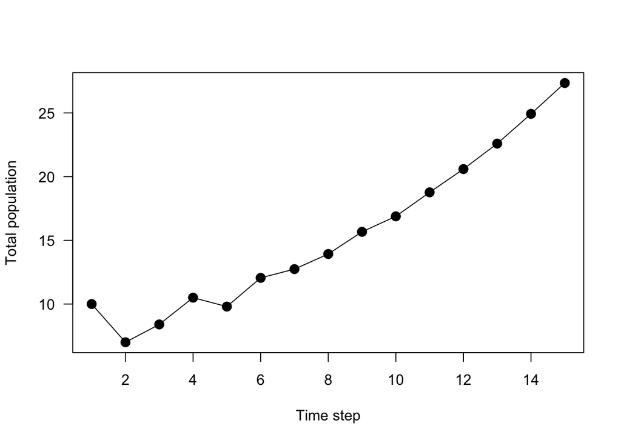

```r
# Set simulation parameters
   n.steps <- 15
   vec.steps <- 1:n.steps
   N <- matrix(data = NA, nrow = length(N0), ncol = n.steps) # 11 to run 10 times after N0
   N[,1] <- N0

# Run loop
   for (i in 2:n.steps) {
      N[,i] <- proj.mat%*%N[,i-1]
   }

# Function to sum columns to give total population size (dimension 2)
   totalN <- apply(X = N, MARGIN = 2, FUN = sum)

# Plot points at each step and connect them with a line
   plot(x = vec.steps, y = totalN, type = "l", las = 1, xlab = "Time step", ylab = "Total population")
   points(x = vec.steps, y = totalN, pch = 16, cex = 1.5)
```

### 2.2

From the data in exercise 2.1, plot the logarithm of the population density over time. What equation would best fit these data? Also graph the data from only the last time time periods (times 11-15). What equation would best fit these data?

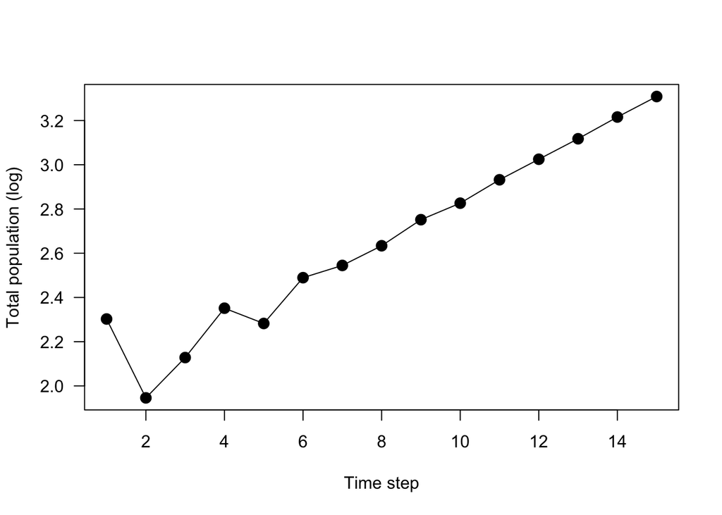

```r
log_totalN <- log(totalN)
plot(x = vec.steps, y = log_totalN, type = "l", las = 1, xlab = "Time step", ylab = "Total population (log)")
points(x = vec.steps, y = log_totalN, pch = 16, cex = 1.5)
```

It’s not a smooth curve, so it’s difficult to describe an equation to fit these data.

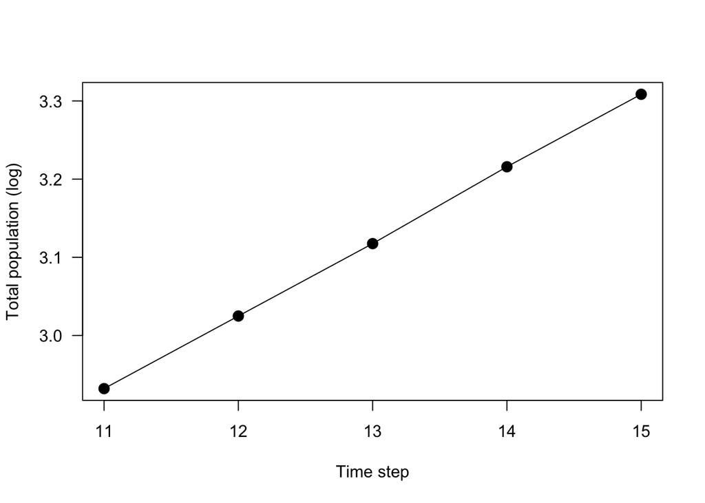

```r
log_totalN <- log(totalN)
last.five <- (length(vec.steps)-4):length(vec.steps)
plot(x = vec.steps[last.five], y = log_totalN[last.five], type = "l", las = 1, xlab = "Time step", ylab = "Total population (log)")
points(x = vec.steps[last.five], y = log_totalN[last.five], pch = 16, cex = 1.5)
```

Plotting the last 5 time steps, you can see that there is log-linear growth through time, just like with density-independent growth.

### 2.3.

From the projection in exercise 2.1, plot the population densities of the age categories over time. Compare the pattern with the results of exercise 2.1.

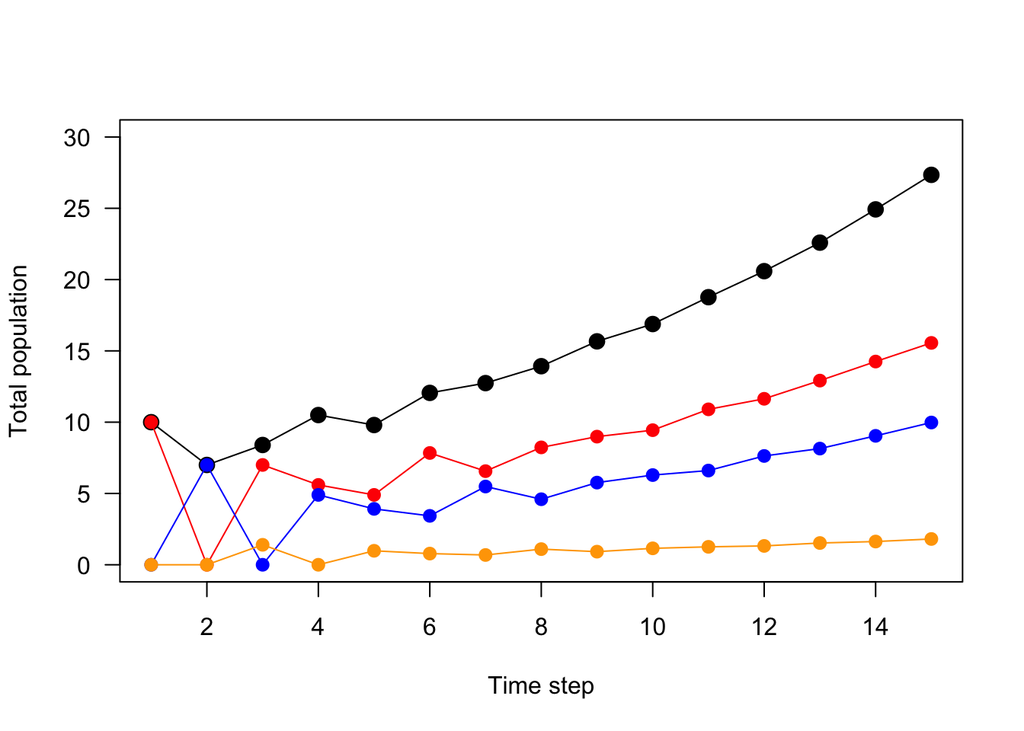

```r
plot(x = vec.steps, y = totalN, type = "l", las = 1, xlab = "Time step", ylab = "Total population", ylim = c(0, 30))
    points(x = vec.steps, y = totalN, pch = 16, cex = 1.5)
  lines(x = vec.steps, y = N[1,], col = "red")
    points(x = vec.steps, y = N[1,], col = "red", pch = 16, cex = 1.25)
  lines(x = vec.steps, y = N[2,], col = "blue")
    points(x = vec.steps, y = N[2,], col = "blue", pch = 16, cex = 1.25)
  lines(x = vec.steps, y = N[3,], col = "orange")
    points(x = vec.steps, y = N[3,], col = "orange", pch = 16, cex = 1.25)
```

Each age fluctuates early in the timeseries and then stabilize. Each age seems to fluctualte more than the total population.

### 2.4

Given the projection matrix
$$\begin{bmatrix}
0 & 3 & 8 & 1 \\
0.7 & 0 & 0 & 0 \\
0 & 0.3 & 0 & 0 \\
0 & 0 & 0.1 & 0
\end{bmatrix}$$
supopose the population is introduced onto an island with 10 of the oldest individuals. Project the population 20 times, and graph the total number over time.

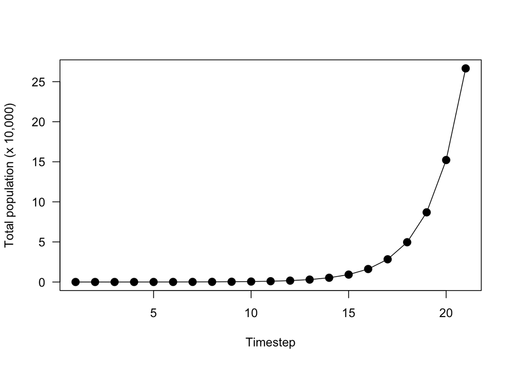

```r
n.steps <- 21
vec.steps <- 1:n.steps
proj.mat4 <- matrix(c(0, 0.7, 0, 0, 3, 0, 0.3, 0, 8, 0, 0, 0.1, 1, 0, 0, 0), nrow = 4, ncol = 4)
N0 <- matrix(data = c(0, 0, 0, 10), ncol = 1)
N <- matrix(data = NA, nrow = length(N0), ncol = n.steps)
N[,1] <- N0
for (i in 2:n.steps) {
  N[,i] <- proj.mat4%*%N[,i-1]
}
total.N <- apply(X = N, MARGIN = 2, FUN = sum)/10000
plot(x = vec.steps, y = total.N, type = "l", las = 1, xlab = "Timestep", ylab = "Total population (x 10,000)")
  points(x = vec.steps, y = total.N, pch = 16, cex = 1.5)
```

### 2.13

Given the projection matrix $\Bigl[ \begin{smallmatrix}0 & 3 \\ 0.9 & 0\end{smallmatrix}\Bigr],$ compute the eigenvalues. Beginning with $N_1 = 21.5$ and $N_2 = 23.6$, project the final matrix forward 30 times, plot the log of the total number against time, and estimate the rate of population growth from a line drawn on the plot. (Recall from the previous chapter what the exponential rate of incrase looks like after taking a natural logs.) Does the estimate of the finite rate of population increase correspond to the computation of the dominant eigenvalue? Note here that a model in which only one category produces offspring has some unusual behaviors, and we include one here only to illustrate the general correspondence with the direct calculation of the eigenvalues and the prohjected population.

The eigenvalue would be solving for $\lambda$ in $\lambda ^2 - gm = 0 = \lambda ^2 - 3(0.9)$ means that $\lambda = 1.643168$.

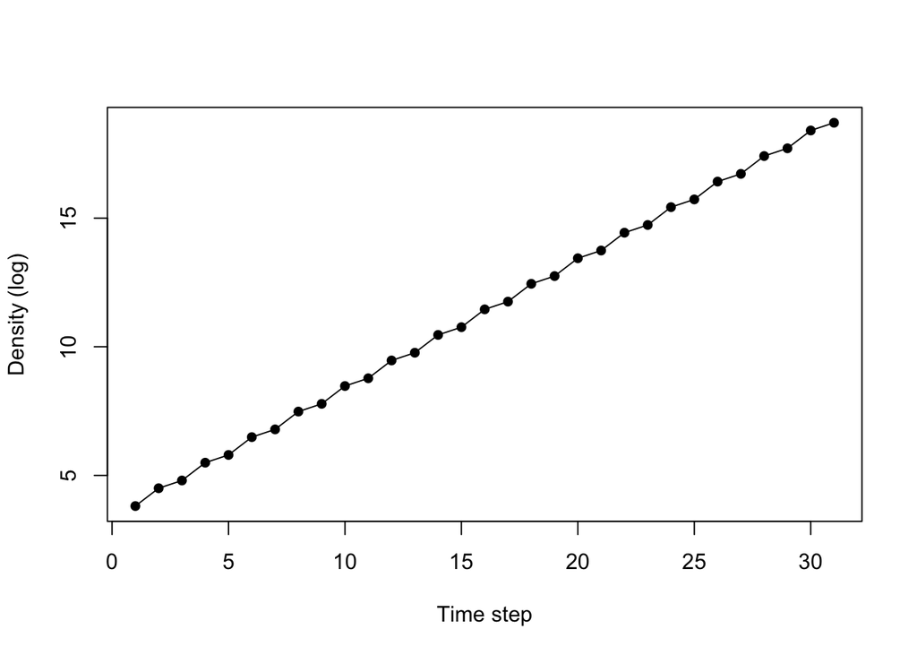

```r
n.steps_2.13 <- 31
vec.steps_2.13 <- 1:n.steps_2.13
proj.mat_2.13 <- matrix(data = c(0, 0.9, 3, 0), nrow = 2, ncol = 2)
N0_2.13 <- matrix(data = c(21.5, 23.6), ncol = 1)
N_2.13 <- matrix(data = NA, nrow = length(N0_2.13), ncol = n.steps_2.13)
N_2.13[,1] <- N0_2.13
for (i in 2:n.steps_2.13) {
  N_2.13[,i] <- proj.mat_2.13%*%N_2.13[,(i-1)]
}
total.N_2.13 <- apply(X = N_2.13, MARGIN = 2, FUN = sum)
total.N_2.13_log <- log(total.N_2.13)
plot(x = vec.steps_2.13, y = total.N_2.13_log, xlab = "Time step", ylab = "Density (log)", pch = 16)
  lines(x = vec.steps_2.13, y = total.N_2.13_log)
```

```r
# estimate line and compare
lm.out_2.13 <- lm(formula = total.N_2.13_log ~ vec.steps_2.13)
slope_2.13 <- lm.out_2.13$coefficients[2]
message(paste0("Your slope is ", round(slope_2.13, digits = 5), ". Raising e to that power, that gives you ", round(exp(slope_2.13), digits = 5),". Compare that with the calculated eigenvalue, 1.643168 You are also an astounding user of R. Pat your self on the back."))
## Your slope is 0.49663. Raising e to that power, that gives you 1.64317. Compare that with the calculated eigenvalue, 1.643168 You are also an astounding user of R. Pat your self on the back.
```

I printed out the values using `message()` above. Yes, they perfectly correspond.

### 2.14

Given the projection matrix
$$\Biggl[
\begin{smallmatrix}0&3&8&1 \\ 0.7&0&0&0 \\
0&0.3&0&0 \\
0&0&0.1&0 \end{smallmatrix}\Biggr]$$
, compute the eigenvalues. Project the population starting with the population vector
$$\Biggl[ \begin{smallmatrix}76 \\ 86 \\ 99
\\ 14 \end{smallmatrix}\Biggr]$$
, and directly estimate the dominant eigenvalue. (Note that in these exercises the population behaves with an apparent cycling of either 3 (exercise 2.13) or 4 (exercise 2.14) time units. This is because there is on;y a single category that produces offspring, a restriction we put on the exercise so the eigenvalue could be computed analytically.)

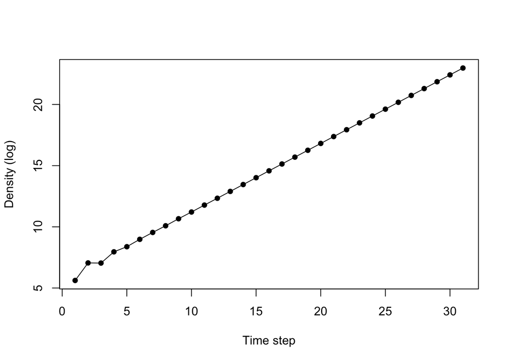

```r
n.steps_2.14 <- 31
vec.steps_2.14 <- 1:n.steps_2.14
proj.mat_2.14 <- matrix(data = c(0, 0.7, 0, 0, 3, 0, 0.3, 0, 8, 0, 0, 0.1, 1, 0, 0, 0), nrow = 4, ncol = 4)
N0_2.14 <- matrix(data = c(76, 86, 99, 14), ncol = 1)
N_2.14 <- matrix(data = NA, nrow = length(N0_2.14), ncol = n.steps_2.14)
N_2.14[,1] <- N0_2.14
for (i in 2:n.steps_2.14) {
  N_2.14[,i] <- proj.mat_2.14%*%N_2.14[,(i-1)]
}
total.N_2.14 <- apply(X = N_2.14, MARGIN = 2, FUN = sum)
total.N_2.14_log <- log(total.N_2.14)
plot(x = vec.steps_2.14, y = total.N_2.14_log, xlab = "Time step", ylab = "Density (log)", pch = 16)
  lines(x = vec.steps_2.14, y = total.N_2.14_log)
```

```r
# estimate line and compare
lm.out_2.14 <- lm(formula = total.N_2.14_log[21:31] ~ vec.steps_2.14[21:31]) #taking the last 11 values because that's a better estimate because the population is closer to reaching a stable age distirbution
slope_2.14 <- lm.out_2.14$coefficients[2]
# calculate eigenvalue
eigenvals <- eigen(proj.mat_2.14)
dom.eig_2.14 <- eigenvals$value[1]
message(paste0("Your slope is ", round(slope_2.14, digits = 5), ". Raising e to that power, that gives you ", round(exp(slope_2.14), digits = 5),". Compare that with the calculated eigenvalue,",round(dom.eig_2.14, digits = 5),"."))
## Your slope is 0.56023. Raising e to that power, that gives you 1.75107. Compare that with the calculated eigenvalue,1.75107+0i.
```

I printed out the values using `message()` above. The log-transformed slope and eigenvalue are equal.

### 2.15

In a population of insects we find that there are, at a particular point in time, 1000 larvae, 50 pupae, and 5 adults. We find that after another census one month later we are able to estimate the probability of survival of a larva (assuming it remains a larva) as 0.7, the probability that the larva will turn into a pupa as 0.2, the probability that a pupa will survive as 0.1, the probability that the pupa will turn into an adult as 0.4, and the probability that an adult will survive as 0.5. Furthermore, an average adult produces 100 eggs, 50% of which appear (within that month) as larvae while the rest die. Construct the population matrix that takes into account all of these probabilities, and project the population one time unit (remember that the time unit is one month).

> In markdown, here is how you create a vector:
> `$$\Biggl[ \begin{smallmatrix} x \\ y \\ z \end{smallmatrix}\Biggr]$$`
> That looks like this:
> $$\Biggl[
> \begin{smallmatrix} x \\ y \\ z \end{smallmatrix}\Biggr]$$
> .

> In markdown, here is how you create a matrix:
> `$$\Biggl[ \begin{smallmatrix} 1 & 2 & 3 \\ 4 & 5 & 6 \\ 7 & 8 & 9 \end{smallmatrix}\Biggr]$$`.
> That looks like this:
> $$\Biggl[
> \begin{smallmatrix} 1 & 2 & 3 \\ 4 & 5 & 6 \\ 7 & 8
> & 9 \end{smallmatrix}\Biggr]$$
> .

First, our vector for population size would be
$$\Biggl[ \begin{smallmatrix} 1000 \\ 50 \\ 5
\end{smallmatrix}\Biggr]$$
. The projection matrix would be
$$\Biggl[ \begin{smallmatrix} 0.7 & 0 & 50
\\ 0.2 & 0.1 & 0 \\ 0 & 0.4 &
0.5 \end{smallmatrix}\Biggr]$$

```r
N0_2.15 <- matrix(data = c(1000, 50, 5), ncol = 1)
proj.mat_2.15 <- matrix(data = c(0.7, 0, 50, 0.2, 0.1, 0, 0, 0.4, 0.5), nrow = 3, ncol = 3, byrow = T)
Nt1 <- proj.mat_2.15%*%N0_2.15
Nt1
```

```
##       [,1]
## [1,] 950.0
## [2,] 205.0
## [3,]  22.5
```

### 2.18

In a population of plants, we categorized individuals as small seedlings, large seedlings, small saplings, large saplings, and adults. Presuming that the plants in each stage either move to the next stage or stay in their own category during population growth, write the state projection matrix in general terms. (That is, fill out a matrix with values that would be 0 and which would not.)

$$\left[ \begin{matrix}p_{00} & 0
& 0 & 0 & f_1 \\ p_{10}& p_{11} & 0 & 0 & 0
\\ 0 & p_{21} & p_{22} & 0 & 0 \\ 0 & 0 & p_{32}
& p_{33} & 0 \\ 0 & 0 & 0 & p_{43} & p_{44}
\end{matrix}\right]$$

### 2.19

At another site this same population has slightly different growth patterns and the variability of its growth is very large, such that occasionall the small seedlings grow all the way to small saplings during a single time unit. Furthermore, because of the severe weather, occasionally a large sapling has its top damaged and actual reverts to the small sapling stage. Modify the matrix of exercise 2.18 to account for these probabilities.

$$\left[ \begin{matrix}p_{00} & 0
& 0 & 0 & f_1 \\ p_{10}& p_{11} & 0 & 0 & 0
\\ p_{20} & p_{21} & p_{22} & p_{23} & 0 \\ 0 & 0
& p_{32} & p_{33} & 0 \\ 0 & 0 & 0 & p_{43}
& p_{44} \end{matrix}\right]$$